# Bar plots

Dr. Emily Burchfield

# Objectives

- This week we’ll learn how to make a number of different bar plots using `geom_bar()` and our EPI dataset.
- I’ll also show you how to apply some custom colors to your plots, and work through advanced labeling.

# Set-up

```r
library(tidyverse)
epi <- readRDS("./data/epir.RDS")
```

# Bar plots

Bar plots are great for visually comparing values of categorical variables. Say you want to use a bar plot to visually compare the population of several countries.

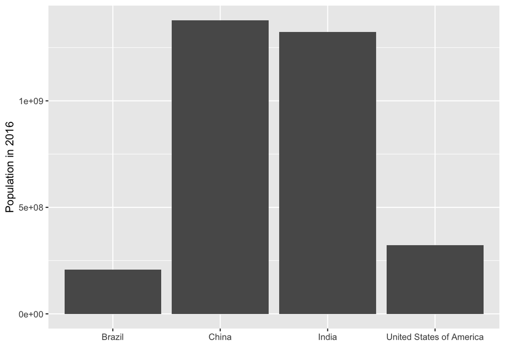

```r
epi_sub <- epi %>%
  filter(country %in% c("China", "India", "United States of America", "Brazil"), year == 2016)

ggplot(epi_sub) +
  geom_bar(aes(x = country, y = POP), stat = "identity") +
  xlab("") +
  ylab("Population in 2016")
```

Not a particularly beautiful plot, but we can clearly see that India and China have massive populations compared to the other countries we’ve selected. There are a few things we can do to make this look much better. First, we can reorder the bars by population:

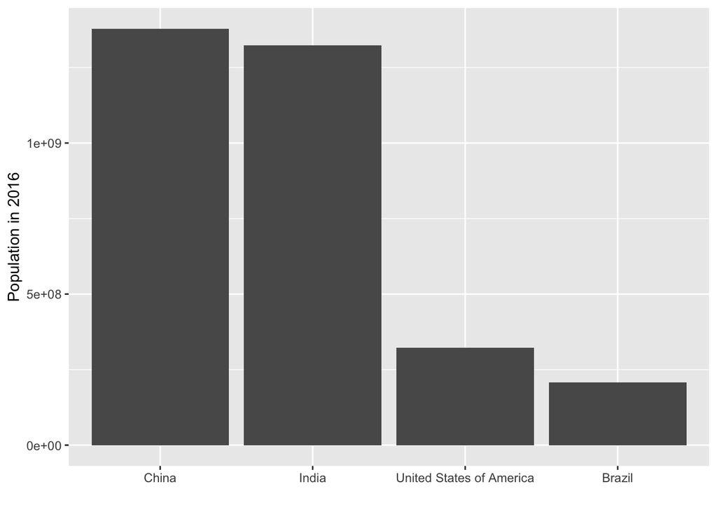

```r
ggplot(epi_sub) +
  geom_bar(aes(x = reorder(country, desc(POP)), y = POP), stat = "identity") +
  xlab("") +
  ylab("Population in 2016")
```

For ascending order, just drop the `desc()` function. Another nice trick is to flip the bar plot to make the axes a bit easier to read:

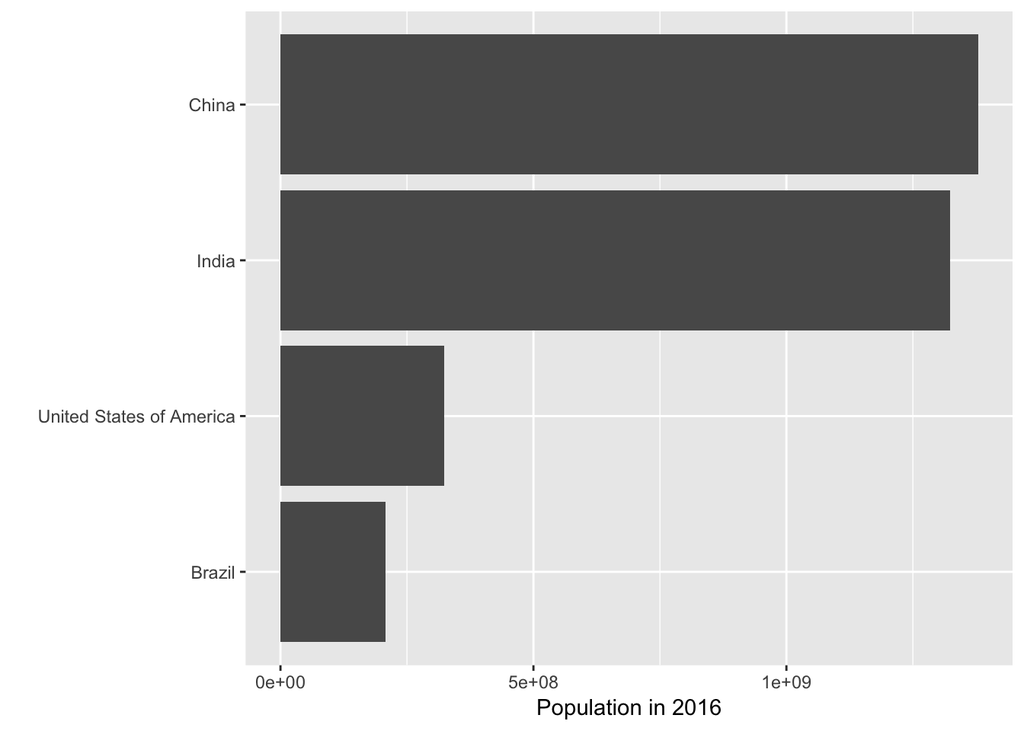

```r
ggplot(epi_sub) +
  geom_bar(aes(x = reorder(country, POP), y = POP), stat = "identity") +
  xlab("") +
  ylab("Population in 2016") +
  coord_flip()
```

We can change the fill color, border color, and transparency of all bars as follows:

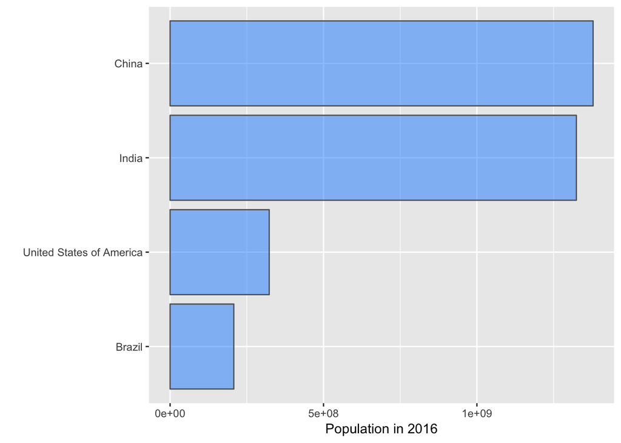

```r
ggplot(epi_sub) +
  geom_bar(aes(x = reorder(country, POP), y = POP), stat = "identity",
           fill = "dodgerblue", color = "grey40", alpha = 0.5) +
  xlab("") +
  ylab("Population in 2016") +
  coord_flip()
```

Here, the `fill` argument refers to the color of the bars, `color` refers to the line around the bars, and `alpha` refers to the transparency of the fill.

We can use the `scales` package to remove the scientific notation on the x-axis and also improve some of our labeling and our theme:

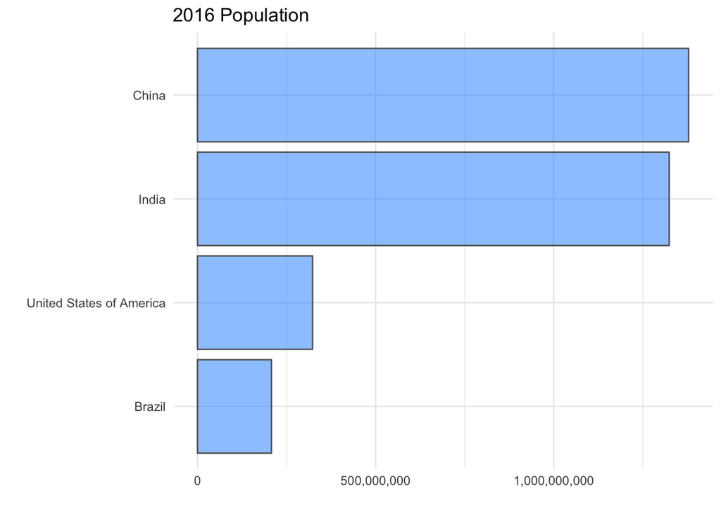

```r
library(scales)
ggplot(epi_sub) +
  geom_bar(aes(x = reorder(country, POP), y = POP), stat = "identity",
           fill = "dodgerblue", color = "grey40", alpha = 0.5) +
  xlab("") +
  ylab("") +
  labs(title = "2016 Population") +
  coord_flip() +
  scale_y_continuous(labels = comma) +
  theme_minimal()
```

…and we could even change our color scheme to fill the color of the bar based on the continent in which it is located by adding a `fill` argument in the `aes()` function:

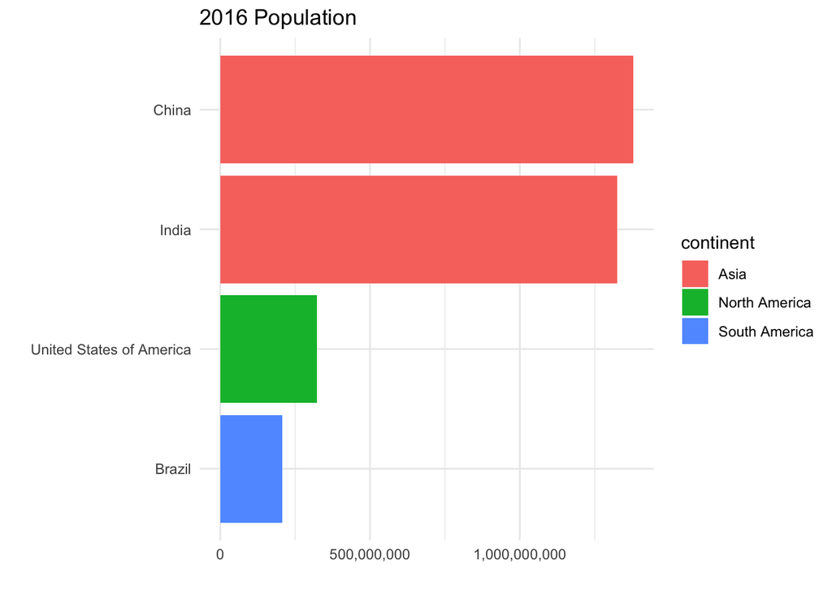

```r
ggplot(epi_sub) +
  geom_bar(aes(x = reorder(country, POP), y = POP, fill = continent), stat = "identity") +
  xlab("") +
  ylab("") +
  labs(title = "2016 Population") +
  coord_flip() +
  scale_y_continuous(labels = comma) +
  theme_minimal()
```

Finally, we can manually change the fill colors as follows:

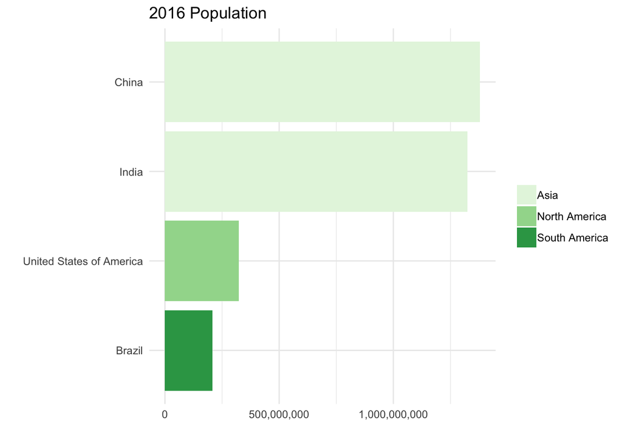

```r
ggplot(epi_sub) +
  geom_bar(aes(x = reorder(country, POP), y = POP, fill = continent), stat = "identity") +
  scale_fill_manual(values = c("#e5f5e0", "#a1d99b", "#31a354")) +
  xlab("") +
  ylab("") +
  labs(title = "2016 Population") +
  coord_flip() +
  scale_y_continuous(labels = comma) +
  theme_minimal() +
  theme(legend.title = element_blank())  # also dropped legend title
```

One last trick that’s good to know with bar plots is that you can play around with the width of the bars by adding a `width` argument to the `geom_bar()` function:

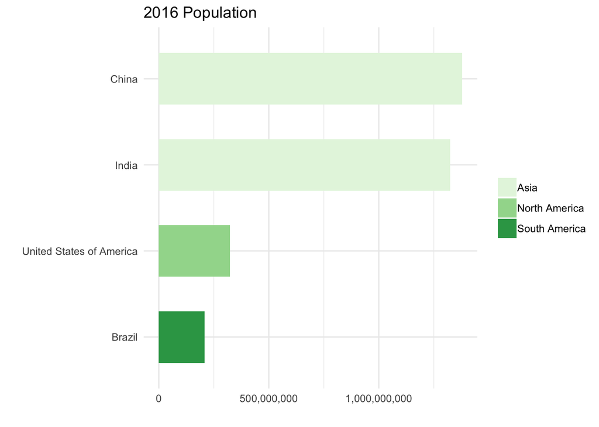

```r
ggplot(epi_sub) +
  geom_bar(aes(x = reorder(country, POP), y = POP, fill = continent), stat = "identity", width = 0.6) +
  scale_fill_manual(values = c("#e5f5e0", "#a1d99b", "#31a354")) +
  xlab("") +
  ylab("") +
  labs(title = "2016 Population") +
  coord_flip() +
  scale_y_continuous(labels = comma) +
  theme_minimal() +
  theme(legend.title = element_blank())  # also dropped legend title
```

Another cool idea is to add labels to each bar. These labels could be the numerical value you are trying to visualize (population in our case):

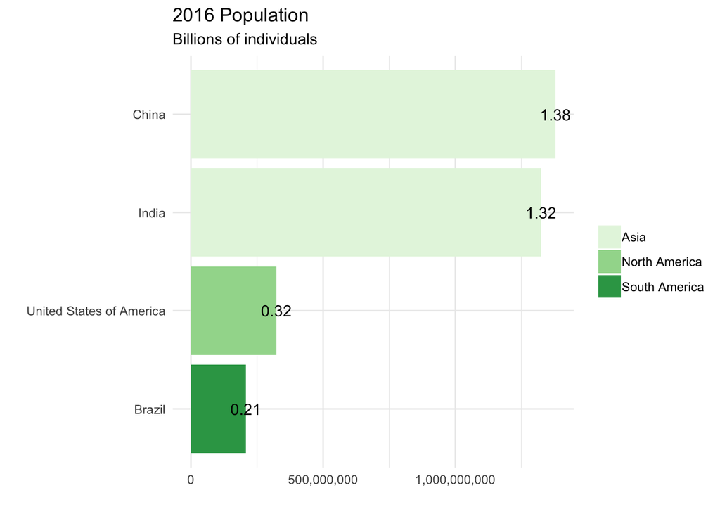

```r
ggplot(epi_sub) +
  geom_bar(aes(x = reorder(country, POP), y = POP, fill = continent), stat = "identity") +
  scale_fill_manual(values = c("#e5f5e0", "#a1d99b", "#31a354")) +
  xlab("") +
  ylab("") +
  labs(title = "2016 Population", subtitle = "Billions of individuals") +
  coord_flip() +
  scale_y_continuous(labels = comma) +
  theme_minimal() +
  theme(legend.title = element_blank())  +
  geom_text(aes(x = reorder(country, POP), y = POP, label = round(POP/1000000000, 2)), nudge_y = 2, color = "black")
```

You can play with the `nudge_x` and `nudge_y` parameters to get the labels where you’d like, or write out as a `svg` and make these changes in InkScape:

```r
ggsave("myfig.svg", my_plot)
```

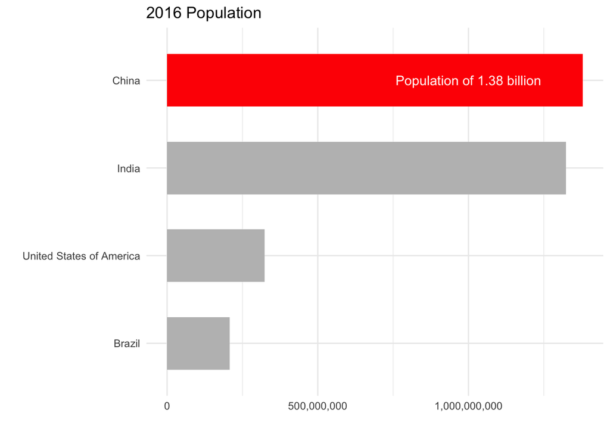

```r
epi_ch <- epi_sub %>% mutate(china = ifelse(country == "China", TRUE, FALSE))

ggplot(epi_ch) +
  geom_bar(aes(x = reorder(country, POP), y = POP, fill = china), stat = "identity", width = 0.6) +
  scale_fill_manual(values = c("grey", "red")) +
  xlab("") +
  ylab("") +
  labs(title = "2016 Population") +
  coord_flip() +
  scale_y_continuous(labels = comma) +
  theme_minimal() +
  theme(legend.position = "none") +
  annotate("text", x = "China", y = 1000000000, label = "Population of 1.38 billion", color = "white")
```

# Additional resources

- [This website](https://uc-r.github.io/barcharts) provides a fantastic overview of the ways you can use bar plots to visualize your data in `R`.